# QTM 151 Final Project

By Ally Gibbs, Vincent Lee, Sammy Brodsky, Zina Alsheklee

```python
import pandas as pd
import numpy as np
import matplotlib.pyplot as plt
import seaborn as sns
```

## Question 1:

What is the relationship between risk exposure from conflict-related violence, work-related insecurity, and civil liberties violations, and the level of realized human rights (as measured by adult survival rates) across Pacific Island nations and Taiwan?

```python
risk_df = pd.read_csv("data/people_at_risk.csv")
rights_df = pd.read_csv("data/Pacific_Taiwan_data.csv", encoding='ISO-8859-1')
```

```python
# Step 1: Define Pacific Island nations and Taiwan

pacific_nations = [
    'Fiji', 'Kiribati', 'Marshall Islands', 'Micronesia', 'Nauru',
    'Palau', 'Papua New Guinea', 'Samoa', 'Solomon Islands',
    'Tonga', 'Tuvalu', 'Vanuatu'
]
comparison_nations = pacific_nations + ['Taiwan']
```

```python
# Step 2: Filter datasets

risk_filtered = risk_df [risk_df[ 'country']. isin(comparison_nations)] .copy()
rights_filtered = rights_df[rights_df ['Country'].isin(comparison_nations)].copy()
```

```python
# Step 3: Get latest human rights score (adult survival rate)

rights_recent = rights_filtered.sort_values ('Year').drop_duplicates(subset=['Country'], keep='last')
rights_recent = rights_recent [['Country', 'Year', 'AdultSurvival_All']].rename(columns={
    'Country': 'country',
    'AdultSurvival_All': 'Adult Survival Rate (%)'
})
rights_recent ['Adult Survival Rate (%)'] = pd.to_numeric(rights_recent['Adult Survival Rate (%)'], errors='coerce')
```

```python
# Step 4: Get latest risk datal

risk_recent = risk_filtered.sort_values( 'year').drop_duplicates(subset=['country'], keep='last')
risk_recent = risk_recent[['country', 'year',
                           'exkill_total_atrisk_resp',  # Conflict Risk
                           'work_total_atrisk_resp',    # Economic/Work Risk
                           'express_total_atrisk_resp'  # Civil Liberties Risk (freedom of expression)
                            ]].rename(columns={
    'exkill_total_atrisk_resp': 'Conflict Risk',
    'work_total_atrisk_resp': 'Work-Related Risk',
    'express_total_atrisk_resp': 'Civil Liberties Risk'
})
```

```python
# Step 5: Merge datasets

merged_df = pd.merge(rights_recent, risk_recent, on='country')
```

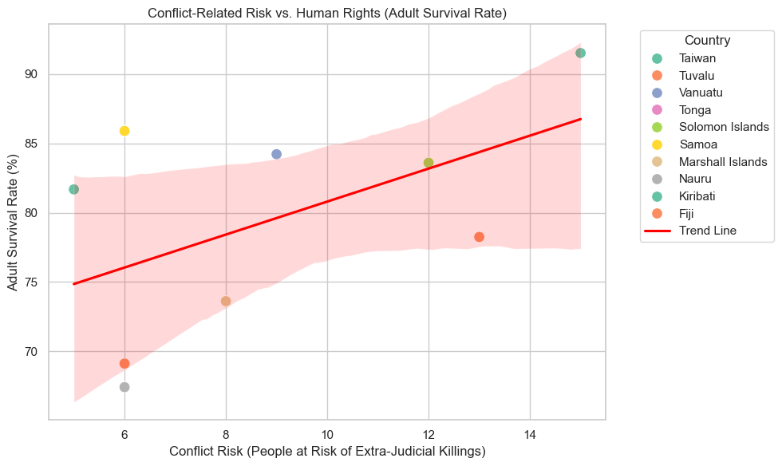

```python
# Step 6: Plot 1 - Conflict Risk vs Human Rights

sns.set(style="whitegrid")
plt.figure(figsize=(10, 6))
sns.scatterplot(data=merged_df, x="Conflict Risk", y="Adult Survival Rate (%)", hue="country", s=100, palette="Set2")
sns.regplot(data=merged_df, x="Conflict Risk", y="Adult Survival Rate (%)", scatter=False, color="red", label="Trend Line")
plt.title("Conflict-Related Risk vs. Human Rights (Adult Survival Rate)")
plt.xlabel("Conflict Risk (People at Risk of Extra-Judicial Killings)")
plt.ylabel("Adult Survival Rate (%)")
plt.legend(title="Country", bbox_to_anchor=(1.05, 1), loc='upper left')
plt.tight_layout()
plt.show()
```

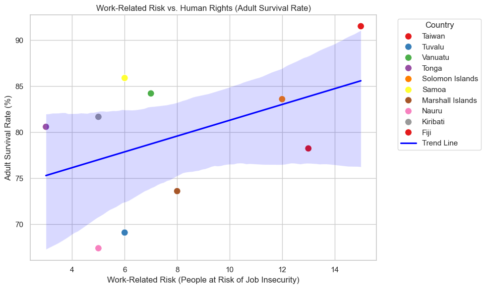

```python
# Step 7: Plot 2 - Work-Related Risk vs Human Rights

plt. figure(figsize=(10, 6))
sns.scatterplot(data=merged_df, x="Work-Related Risk", y="Adult Survival Rate (%)", hue="country", s=100, palette="Set1" )
sns.regplot(data=merged_df, x="Work-Related Risk", y="Adult Survival Rate (%)", scatter=False, color="blue", label="Trend Line")
plt.title("Work-Related Risk vs. Human Rights (Adult Survival Rate)")
plt.xlabel ("Work-Related Risk (People at Risk of Job Insecurity)")
plt.ylabel ("Adult Survival Rate (%)")
plt.legend (title="Country", bbox_to_anchor=(1.05, 1), loc='upper left')
plt.tight_layout()
plt.show()
```

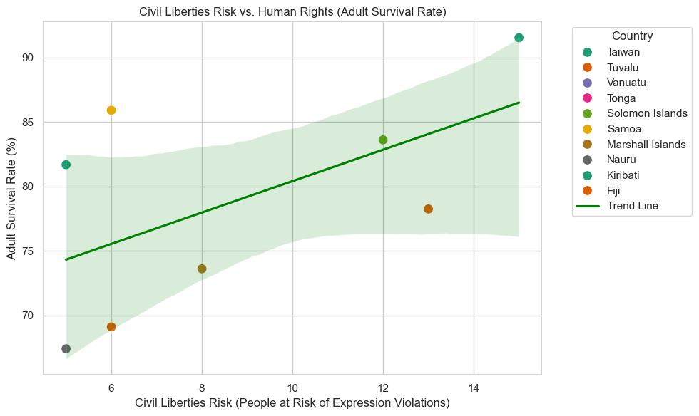

```python
# Step 8: Plot 3 - Civil Liberties Risk vs Human Rights

plt.figure(figsize=(10, 6))
sns.scatterplot(data=merged_df, x="Civil Liberties Risk", y="Adult Survival Rate (%)", hue="country", s=100, palette="Dark2" )
sns.regplot(data=merged_df, x="Civil Liberties Risk", y="Adult Survival Rate (%)", scatter=False, color="green", label="Trend Line")
plt.title("Civil Liberties Risk vs. Human Rights (Adult Survival Rate)")
plt.xlabel("Civil Liberties Risk (People at Risk of Expression Violations)")
plt.ylabel ("Adult Survival Rate (%)")
plt.legend (title="Country", bbox_to_anchor=(1.05, 1), loc='upper left')
plt.tight_layout()
plt.show()
```

```python
# Step 9: Correlation Analysis
correlation_data = merged_df[[
    'Adult Survival Rate (%)',
    'Conflict Risk',
    'Work-Related Risk',
    'Civil Liberties Risk'
]]
correlation_matrix = correlation_data.corr()
print("Correlation Matrix:")
print(correlation_matrix)
```

```
Correlation Matrix:
                         Adult Survival Rate (%)  Conflict Risk  \
Adult Survival Rate (%)                 1.000000       0.534609
Conflict Risk                           0.534609       1.000000
Work-Related Risk                       0.447910       0.982636
Civil Liberties Risk                    0.577976       0.996423

                         Work-Related Risk  Civil Liberties Risk
Adult Survival Rate (%)           0.447910              0.577976
Conflict Risk                     0.982636              0.996423
Work-Related Risk                 1.000000              1.000000
Civil Liberties Risk              1.000000              1.000000
```

### Question 1 Interpretation:

This analysis explores the relationship between different types of human rights risk exposure and the level of realized human rights, as measured by adult survival rates, across Pacific Island nations and Taiwan.

Looking at conflict-related risk, measured as the number of people at risk of extra-judicial killings, there is a moderate positive correlation of +0.53 with adult survival rates. This indicates that countries reporting higher levels of conflict risk also tend to report higher levels of realized human rights, as measured by survival. However, this trend should be interpreted with caution. The relationship is likely influenced by variation in state reporting capacity and institutional transparency, which this analysis does not control for.

## Question 2:

Does a larger gender gap in a right (food, education, health) correspond to a higher proportion of people at risk for that same right?

```python
esr_sex_disaggregated = pd.read_csv('data/esr_sex_disaggregated.csv')
people_at_risk = pd.read_csv('data/people_at_risk.csv')
cpr = pd.read_csv('data/cpr.csv')
```

```python
# Step 1: fix esr columns
esr_sex_disaggregated.rename(columns={
   'Country': 'country',
   'Year': 'year',
   'Country_Code': 'iso3c'
}, inplace=True)
```

```python
# Step 2: map the regions
country_to_region = {
   'Angola': 'Sub-Saharan Africa', 'Argentina': 'Latin America & Caribbean',
   'Australia': 'East Asia & Pacific', 'Austria': 'Europe & Central Asia',
   'Bangladesh': 'South Asia', 'Belgium': 'Europe & Central Asia',
   'Brazil': 'Latin America & Caribbean', 'Canada': 'North America',
   'China': 'East Asia & Pacific', 'Egypt': 'Middle East & North Africa',
   'France': 'Europe & Central Asia', 'Germany': 'Europe & Central Asia',
   'India': 'South Asia', 'Indonesia': 'East Asia & Pacific',
   'Japan': 'East Asia & Pacific', 'Kenya': 'Sub-Saharan Africa',
   'Mexico': 'Latin America & Caribbean', 'Nigeria': 'Sub-Saharan Africa',
   'Pakistan': 'South Asia', 'Russia': 'Europe & Central Asia',
   'Saudi Arabia': 'Middle East & North Africa', 'South Africa': 'Sub-Saharan Africa',
   'United Kingdom': 'Europe & Central Asia', 'United States': 'North America'
}
cpr['region_wb'] = cpr['country'].map(country_to_region)
```

```python
# Step 3: merge everything
merged_df = pd.merge(
   esr_sex_disaggregated,
   cpr[['country', 'year', 'iso3c', 'region_wb']],
   on=['country', 'year', 'iso3c'],
   how='inner'
)
full_merged = pd.merge(
   merged_df,
   people_at_risk.rename(columns={'Country': 'country', 'Year': 'year'}),
   on=['country', 'year'],
   how='inner'
)
```

```python
# Step 4: define rights
rights = {
   'Food': {
       'gap': ('FoodSecure_Female_IAScore', 'FoodSecure_Male_IAScore'),
       'prefix': 'food'
   },
   'Education': {
       'gap': ('TotNetPrimEn_Female_IAScore', 'TotNetPrimEn_Male_IAScore'),
       'prefix': 'educ'
   },
   'Health': {
       'gap': ('AdultSurvival_Female_IAScore', 'AdultSurvival_Male_IAScore'),
       'prefix': 'health'
   }
}
```

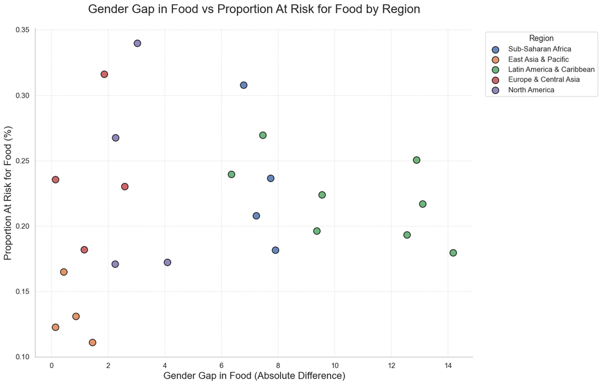

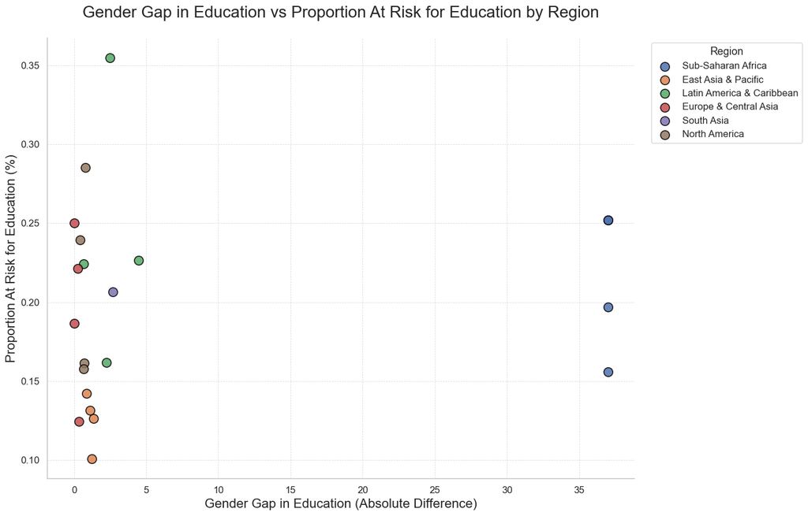

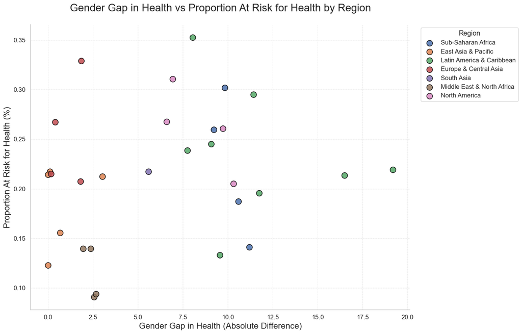

```python
# Step 5: plot
for right_label, components in rights.items():
   female_col, male_col = components['gap']
   prefix = components['prefix']
   # Create gender gap
   full_merged[f'{prefix}_gap'] = np.abs(full_merged[female_col] - full_merged[male_col])
   # Average PaR proportion across identities
   prop_cols = [col for col in full_merged.columns if col.startswith(f'{prefix}_atrisk_prop')]
   full_merged[f'{prefix}_at_risk_avg'] = full_merged[prop_cols].mean(axis=1)
   # Drop missing
   plot_data = full_merged.dropna(subset=[f'{prefix}_gap', f'{prefix}_at_risk_avg', 'region_wb'])
   # Plot
   regions = plot_data['region_wb'].unique()
   colors = plt.cm.Set2(np.linspace(0, 1, len(regions)))
   fig, ax = plt.subplots(figsize=(14, 9))
   for i, region in enumerate(regions):
       region_data = plot_data[plot_data['region_wb'] == region]
       ax.scatter(
           region_data[f'{prefix}_gap'],
           region_data[f'{prefix}_at_risk_avg'],
           label=region,
           s=120,
           alpha=0.85,
           edgecolors='black',
           linewidth=1.2
       )
   ax.set_title(f'Gender Gap in {right_label} vs Proportion At Risk for {right_label} by Region', fontsize=20, pad=25)
   ax.set_xlabel(f'Gender Gap in {right_label} (Absolute Difference)', fontsize=16)
   ax.set_ylabel(f'Proportion At Risk for {right_label} (%)', fontsize=16)
   ax.grid(True, linestyle='--', linewidth=0.6, alpha=0.7)
   ax.legend(title='Region', bbox_to_anchor=(1.02, 1), loc='upper left', fontsize=12, title_fontsize=13)
   ax.spines['top'].set_visible(False)
   ax.spines['right'].set_visible(False)
   plt.xticks(fontsize=12)
   plt.yticks(fontsize=12)
   plt.tight_layout()
   plt.show()
```

```python
# Step 6: correlation results with Sub-Saharan Africa excluded for Education
print("Correlation between Gender Gap and Proportion At Risk:\n")
for right_label, components in rights.items():
    female_col, male_col = components['gap']
    prefix = components['prefix']
    gap_col = f'{prefix}_gap'
    risk_col = f'{prefix}_at_risk_avg'
    # Drop missing values
    data = full_merged.dropna(subset=[gap_col, risk_col, 'region_wb'])
    # Exclude Sub-Saharan Africa for Education
    if right_label == 'Education':
        data = data[data['region_wb'] != 'Sub-Saharan Africa']
    if not data.empty:
        corr = np.corrcoef(data[gap_col], data[risk_col])[0, 1]
        print(f"{right_label} (Excl. SSA for Education): {corr:.3f}")
    else:
        print(f"{right_label}: Not enough data")
```

```
Correlation between Gender Gap and Proportion At Risk:

Food (Excl. SSA for Education): 0.143
Education (Excl. SSA for Education): 0.183
Health (Excl. SSA for Education): 0.221
```

### Question 2 Insight:

This analysis investigates whether larger gender gaps in the rights to food, education, and health are associated with a higher proportion of people at risk of deprivation in those same domains.

For the right to food, the correlation between the gender gap in food security and the proportion of people at risk is +0.14, indicating a slight positive relationship. Countries with larger disparities between women’s and men’s food security tend to report somewhat higher proportions of people at risk of lacking sufficient food. Regions such as Latin America and Sub-Saharan Africa display both notable gender gaps and elevated risk levels.

In the area of education, after excluding Sub-Saharan Africa—which exhibits unusually large gender gaps—the correlation rises slightly to +0.18. This suggests that countries with bigger differences between girls’ and boys’ primary school enrollment are slightly more likely to face higher proportions of people at risk of educational deprivation. Without accounting for Sub-Saharan Africa, the relationship appears clearer, though the overall association remains weak. In Sub-Saharan Africa, there is a large gender gap in education, so in order to decrease variance, it is best to exclude this region.

For health, measured through adult survival rates, the correlation is +0.22, marking the strongest relationship among the three rights. Countries with greater gender gaps in survival outcomes tend to show higher proportions of people at risk of health insecurity. Latin America and the Caribbean stand out for having both high gender gaps and elevated health risks, while East Asia and the Pacific display lower values on both dimensions.

Across food, education, and health, larger gender gaps in basic rights are consistently associated with slightly higher perceived risk of rights violations, with health showing the most robust relationship. Still, these correlations are quite low, suggesting that while gender disparities in outcomes may influence perceived rights risk, other social, political, or structural factors likely play a substantial role in shaping expert assessments. These patterns also highlight the need to address gender disparities as part of broader strategies for improving human rights protections and reducing risk exposure.

## Question 3:

How have survival rates changed over time for men and women in the Pacific Island countries and territories?

```python
pacific = pd.read_csv('data/Pacific_Taiwan_data.csv', encoding='latin1')
esr_sex_disaggregated = pd.read_csv('data/esr_sex_disaggregated.csv')
esr_lmy_globalbest = pd.read_csv('data/esr_lmy_globalbest.csv')
esr_lmy_incomeadjusted = pd.read_csv('data/esr_lmy_incomeadjusted.csv')
esr_hiy_incomeadjusted = pd.read_csv('data/esr_hiy_incomeadjusted.csv')
esr_hiy_globalbest = pd.read_csv('data/esr_hiy_globalbest.csv')
```

```python
pd.options.mode.chained_assignment = None

pacific['AdultSurvival_All'] = pd.to_numeric(pacific['AdultSurvival_All'], errors='coerce')
pacific['AdultSurvival_Male'] = pd.to_numeric(pacific['AdultSurvival_Male'], errors='coerce')
pacific['AdultSurvival_Female'] = pd.to_numeric(pacific['AdultSurvival_Female'], errors='coerce')

average_survival_by_year_all = pacific.groupby('Year')['AdultSurvival_All'].mean().reset_index()
average_survival_by_year_male = pacific.groupby('Year')['AdultSurvival_Male'].mean().reset_index()
average_survival_by_year_female = pacific.groupby('Year')['AdultSurvival_Female'].mean().reset_index()

years_to_display = (1990, 1995, 2000, 2005, 2010, 2015, 2020)

filtered_pacific = pacific[pacific['Year'].isin(years_to_display)]

for col in ['AdultSurvival_All', 'AdultSurvival_Male', 'AdultSurvival_Female']:
    filtered_pacific[col] = filtered_pacific[col].astype(str).str.split('.').str[0]
    filtered_pacific[col] = pd.to_numeric(filtered_pacific[col], errors='coerce')

survival_rates = filtered_pacific.groupby('Year')[['AdultSurvival_All', 'AdultSurvival_Male', 'AdultSurvival_Female']].mean().reset_index()

display(survival_rates)
```

|  | Year | AdultSurvival_All | AdultSurvival_Male | AdultSurvival_Female |
| --- | --- | --- | --- | --- |
| 0 | 1990.0 | 76.909091 | 72.590909 | 82.136364 |
| 1 | 1995.0 | 78.227273 | 74.409091 | 82.772727 |
| 2 | 2000.0 | 79.772727 | 76.000000 | 84.181818 |
| 3 | 2005.0 | 80.818182 | 77.090909 | 84.863636 |
| 4 | 2010.0 | 81.272727 | 77.772727 | 85.181818 |
| 5 | 2015.0 | 81.818182 | 78.409091 | 85.409091 |
| 6 | 2020.0 | 82.636364 | 79.136364 | 86.318182 |

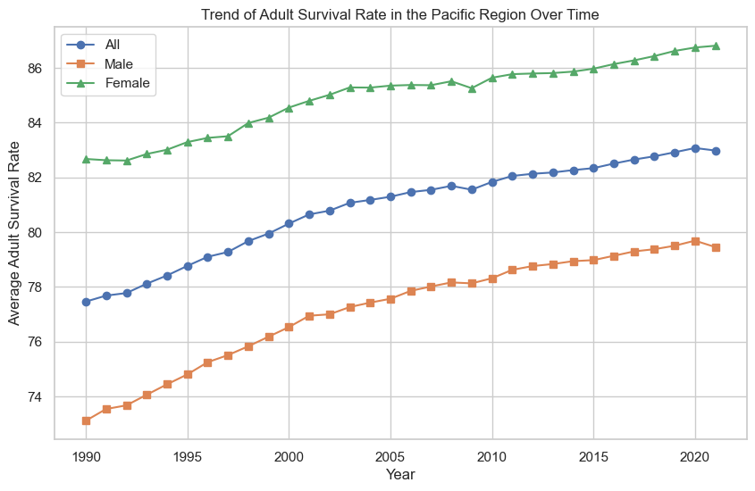

```python
plt.figure(figsize=(10, 6))
plt.plot(average_survival_by_year_all['Year'], average_survival_by_year_all['AdultSurvival_All'], marker='o', label='All')
plt.plot (average_survival_by_year_male['Year'], average_survival_by_year_male['AdultSurvival_Male'], marker='s', label='Male')
plt.plot(average_survival_by_year_female['Year'], average_survival_by_year_female['AdultSurvival_Female'], marker='^', label='Female')
plt.title('Trend of Adult Survival Rate in the Pacific Region Over Time')
plt.xlabel('Year')
plt.ylabel('Average Adult Survival Rate')
plt.grid(True)
plt.legend()
plt.show()
```

```python
for col in ['AdultSurvival_All', 'AdultSurvival_Male']:
    pacific[col] = pacific[col].astype(str).str.split('.').str[0]
    pacific[col] = pd.to_numeric(pacific[col], errors='coerce')

years_to_display = [1990, 2005, 2020]
filtered_pacific = pacific[pacific['Year'].isin(years_to_display)]

country_year_survival = filtered_pacific.groupby(['Country', 'Year'])[['AdultSurvival_All']].mean().reset_index()

max_survival_by_country = country_year_survival.groupby('Country')['AdultSurvival_All'].max().reset_index()

sorted_countries = max_survival_by_country.sort_values(by=['AdultSurvival_All'], ascending=False)['Country'].tolist()
```

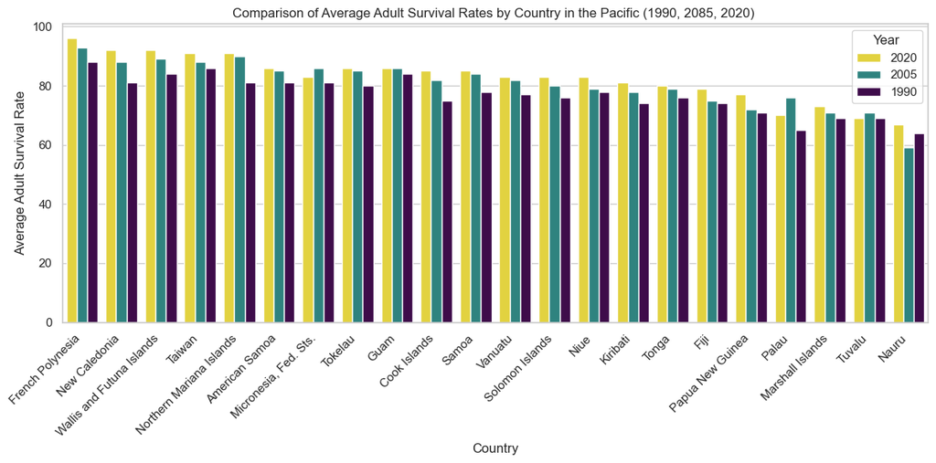

```python
plt.figure(figsize=(12, 6))

viridis_colors = plt.cm.viridis(np.linspace(0, 1, 3))
color_order = [viridis_colors[2], viridis_colors[1], viridis_colors [0]]

sns.barplot(
    x='Country',
    y='AdultSurvival_All',
    hue= 'Year',
    data=country_year_survival,
    palette=color_order,
    dodge=True,
    hue_order=[2020, 2005, 1990],
    order=sorted_countries,
)

plt. title('Comparison of Average Adult Survival Rates by Country in the Pacific (1990, 2085, 2020) ')
plt.xlabel('Country')
plt.ylabel('Average Adult Survival Rate')
plt.xticks(rotation=45, ha='right')
plt.tight_layout()
plt.legend (title='Year')
plt.show()
```

### Question 3 Interpretation

Although the analysis did not calculate formal correlations, the data suggest that countries with historically higher survival rates tend to retain that advantage over time, reflecting underlying structural factors such as health system capacity, governance, and economic stability. It’s important to interpret these findings with caution, as some of the observed improvements may partly reflect changes in data reporting, health surveillance systems, or external support over time.

Overall, while the Pacific region has seen encouraging gains in adult survival over the past 30 years, the persistence of gender and geographic disparities underscores the need for targeted interventions to ensure more equitable health outcomes across populations.